# Assignment 2: Wifi Analysis

Cooper Corbett

8/6/20

# Report

```r
library("tidyr")
library("readr")
library("dplyr")
library("kableExtra")
library("ggplot2")
library("ggthemr")

study <- read.csv("scans/study_wifi_scan.csv", header = TRUE)
study$Location <- "Study"
bedroom <- read.csv("scans/bedroom_wifi_scan.csv", header = TRUE)
bedroom$Location <- "Bedroom"
backyard <- read.csv('scans/backyard_wifi_scan.csv', header = TRUE)
backyard$Location <- "Backyard"
front <- read.csv('scans/front_wifi_scan.csv', header = TRUE)
front$Location <- "Frontyard"
garage <- read.csv('scans/garage_wifi_scan.csv', header = TRUE)
garage$Location <- "Garage"
upstairs_back <- read.csv('scans/upstairsback_wifi_scan.csv', header = TRUE)
upstairs_back$Location <- "Upstairs Back"
upstairs_mid <- read.csv('scans/upstairsmid_wifi_scan.csv', header = TRUE)
upstairs_mid$Location <- "Upstairs Mid"
side <- read.csv('scans/side_wifi_scan.csv', header = TRUE)
side$Location <- "Side"
lounge_room <- read.csv('scans/loungeroom_wifi_scan.csv', header = TRUE)
lounge_room$Location <- "Lounge Room"

wifi_scan <- rbind(study,bedroom,backyard,front,garage,upstairs_back,upstairs_mid,side,lounge_room) %>% lapply(trimws) %>% as.data.frame()
wifi_scan$RSSI <- as.numeric(as.character(wifi_scan$RSSI))
wifi_scan$Channel <- as.factor(as.character(wifi_scan$Channel))
wifi_scan$Width <- as.factor(as.character(wifi_scan$Width))
wifi_scan$Location <- as.factor(as.character(wifi_scan$Location))
wifi_scan$Type <- as.factor(as.character(wifi_scan$Type))
wifi_scan$Auth <- as.factor(as.character(wifi_scan$Auth))
wifi_scan$RSN.MCast <- as.factor(as.character(wifi_scan$RSN.MCast))
wifi_scan$RSN.USCast <- as.factor(as.character(wifi_scan$RSN.USCast))



networks <- wifi_scan %>% distinct(BSSID, .keep_all = TRUE) %>% arrange(-RSSI)#%>% filter(Network.Name != 'NA')
networks.no_name <- wifi_scan %>% distinct(BSSID, .keep_all = TRUE) %>% filter(Length == 0)
```

## Map

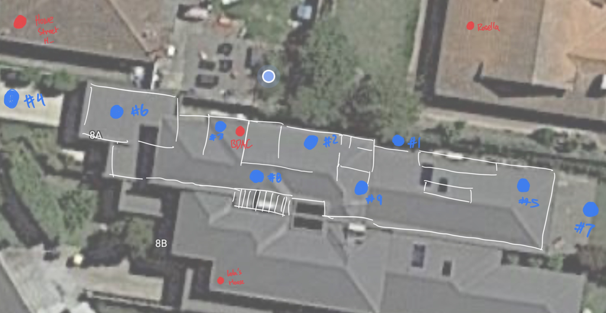

```r
knitr::include_graphics("map.jpg")
```

```r
location_key <- cbind(
  Location = levels(wifi_scan$Location),
  Key = c(3,2,7,4,6,9,8,1,5)
) %>% as.data.frame()

location_key %>% kable(row.names = F, caption = "Map - Location Key", full_width = F) %>% kable_styling(bootstrap_options = c("striped", "hover", "condensed"))
```

Map - Location Key

| Location | Key |
| --- | --- |
| Backyard | 3 |
| Bedroom | 2 |
| Frontyard | 7 |
| Garage | 4 |
| Lounge Room | 6 |
| Side | 9 |
| Study | 8 |
| Upstairs Back | 1 |
| Upstairs Mid | 5 |

#### Scanned Networks

The Mac OSX in-built Wi-Fi Diagnostics scanning tool has been utilised to obtain the data found in this report. Network characteristics were gathered at each scanning location (see above Map), and saved to a CSV file for later processing. These CSV files required pre-processing and tidying prior to import into R - which required bespoke Python formatting scripts.

The Top 15 networks discovered (determined by recorded signal strength) have been detailed in *Table A* below.

```r
networks[1:15,] %>% select(colnames(networks)[1:11], Location, -Length, -Bytes) %>% kable(row.names = F, caption = "Table A: Top 15 BSSID by Signal Strength", full_width = FALSE) %>% kable_styling(bootstrap_options = c("striped", "hover", "condensed"))%>% kableExtra::scroll_box(width = "100%")
```

Table A: Top 15 BSSID by Signal Strength

| Network.Name | BSSID | Channel | Width | Country | Type | RSSI | RSN.MCast | RSN.USCast | Location |
| --- | --- | --- | --- | --- | --- | --- | --- | --- | --- |
| NA | e6:63:da:1b:03:91 | 6 | 20 | AU | 11n | -32 | aes_ccm | aes_ccm | Study |
| BDAC (2.4Ghz) | e0:63:da:1b:03:91 | 6 | 20 | AU | 11n | -32 | aes_ccm | aes_ccm | Study |
| NA | e2:63:da:1c:03:91 | 36 | 80 | AU | 11ac | -35 | NA | NA | Study |
| NA | e6:63:da:1c:03:91 | 36 | 80 | AU | 11ac | -35 | aes_ccm | aes_ccm | Study |
| NA | ea:63:da:1c:03:91 | 36 | 80 | AU | 11ac | -35 | aes_ccm | aes_ccm | Study |
| NA | ee:63:da:1c:03:91 | 36 | 80 | AU | 11ac | -35 | aes_ccm | aes_ccm | Study |
| BDAC (2.4Ghz) | e0:63:da:1c:03:91 | 36 | 80 | AU | 11ac | -35 | aes_ccm | aes_ccm | Study |
| hejpadig | 18:90:d8:80:44:51 | 1 | 20 | AU | 11n | -51 | tkip | aes_ccm tkip | Frontyard |
| Lolas House | 70:3a:cb:92:eb:b1 | 11 | 20 | au | 11n | -60 | aes_ccm | aes_ccm | Study |
| Lolas House | 70:3a:cb:91:79:8f | 1 | 20 | au | 11n | -61 | aes_ccm | aes_ccm | Study |
| NETGEAR83 | 9c:3d:cf:2d:4e:02 | 4 | 20 | AU | 11n | -62 | aes_ccm | aes_ccm | Backyard |
| NetComm 5278 | 18:f1:45:7c:6b:8e | 1 | 40 | NA | 11n | -63 | aes_ccm | aes_ccm | Study |
| ROSELLA | 3c:37:86:62:99:a9 | 4 | 20 | NA | 11n | -69 | aes_ccm | aes_ccm | Backyard |
| TelstraC6EAD5 | a4:91:b1:c6:ea:d5 | 9 | 20 | NA | 11n | -72 | aes_ccm | aes_ccm | Backyard |
| NA | a6:91:b1:c6:ea:df | 108 | 80 | AU | 11ac | -73 | aes_ccm | aes_ccm | Backyard |

#### Channel Occupancy

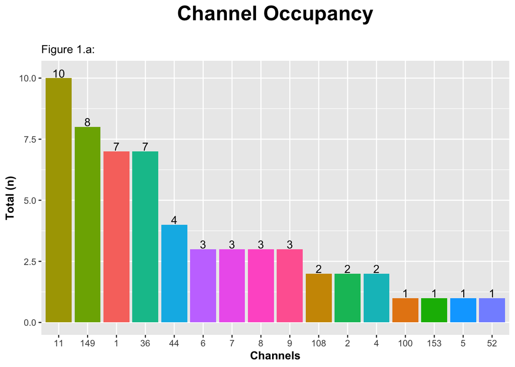

```r
networks.channel.occupancy <- networks %>% group_by(Channel) %>% count()
networks.channel.occupancy <- networks.channel.occupancy[order(-networks.channel.occupancy$n),]
totals <- networks.channel.occupancy %>%
    group_by(Channel) %>%
    summarize(total = sum(n))
#ggplot(data = networks.channel.occupancy) + geom_col(aes(x=reorder(Channel,-n), y=n, fill = Channel))

networks.channel.occupancy.by_location <- networks %>% group_by(Channel, Location) %>% count()
networks.channel.occupancy.by_location <- networks.channel.occupancy.by_location[order(-networks.channel.occupancy.by_location$n),]
ggplot(data = networks.channel.occupancy.by_location) +
  geom_col(aes(x=reorder(Channel, -n, sum), y=n, fill = Channel), position = "stack") +
  geom_text(data=totals,aes(x=Channel, y=(total + 0.2), label = total)) +
  no_legend() +
  labs(title = "Channel Occupancy", subtitle = "Figure 1.a:") +
  xlab("Channels") +
  ylab("Total (n)") +
  theme(plot.title = element_text(hjust = 0.5, margin = ggplot2::margin(b=20), face = "bold", size = 20), plot.caption = element_text(hjust = 0, size = 10, margin = ggplot2::margin(t=20)), axis.title = element_text(face = "bold"), legend.title = element_text(face = "bold"))
```

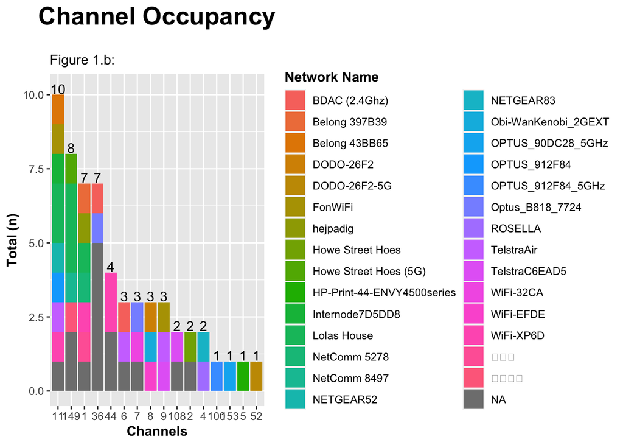

```r
networks.channel.occupancy.by_network <- networks %>% group_by(Channel, Network.Name) %>% count()
networks.channel.occupancy.by_network <- networks.channel.occupancy.by_network[order(-networks.channel.occupancy.by_network$n),]
ggplot(data = networks.channel.occupancy.by_network) +
  geom_col(aes(x=reorder(Channel, -n, sum), y=n, fill = Network.Name), position = "stack") +
  geom_text(data=totals,aes(x=Channel, y=(total + 0.2), label = total)) +
  labs(title = "Channel Occupancy", subtitle = "Figure 1.b:") +
  xlab("Channels") +
  scale_fill_discrete(name = "Network Name") +
  ylab("Total (n)") +
  theme(plot.title = element_text(hjust = 0.5, margin = ggplot2::margin(b=20), face = "bold", size = 20), plot.caption = element_text(hjust = 0, size = 10, margin = ggplot2::margin(t=20)), axis.title = element_text(face = "bold"), legend.title = element_text(face = "bold"))
```

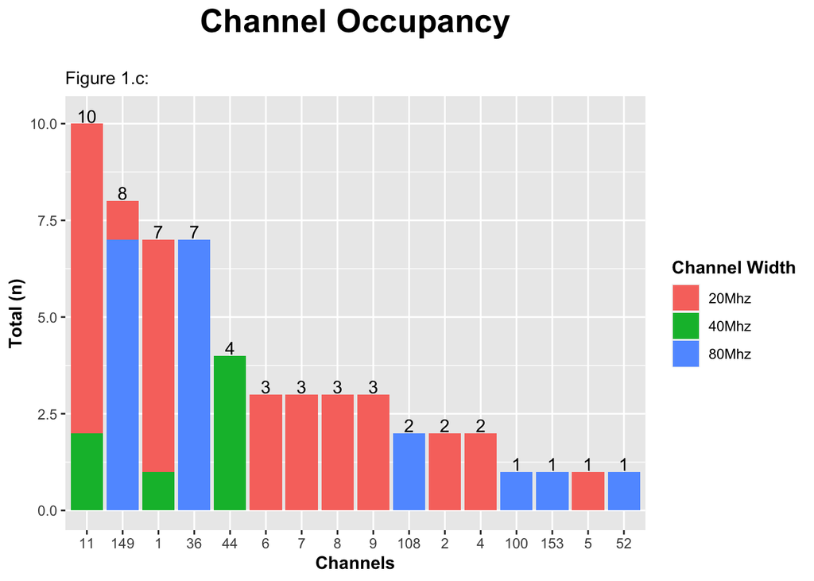

```r
networks.channel.occupancy.by_network <- networks %>% group_by(Channel, Network.Name, Width) %>% count()
networks.channel.occupancy.by_network <- networks.channel.occupancy.by_network[order(-networks.channel.occupancy.by_network$n),]
ggplot(data = networks.channel.occupancy.by_network) +
  geom_col(aes(x=reorder(Channel, -n, sum), y=n, fill = Width), position = "stack") +
  geom_text(data=totals,aes(x=Channel, y=(total + 0.2), label = total)) +
  labs(title = "Channel Occupancy", subtitle = "Figure 1.c:") +
  xlab("Channels") +
  scale_fill_discrete(name = "Channel Width", labels = c("20Mhz", "40Mhz", "80Mhz")) +
  ylab("Total (n)") +
  theme(plot.title = element_text(hjust = 0.5, margin = ggplot2::margin(b=20), face = "bold", size = 20), plot.caption = element_text(hjust = 0, size = 10, margin = ggplot2::margin(t=20)), axis.title = element_text(face = "bold"), legend.title = element_text(face = "bold"))
```

```r
networks.channel.count <- networks %>% group_by(Network.Name) %>% count()
networks.channel.count <- networks.channel.count[order(-networks.channel.count$n),]
```

#### Interference and Signal Strength

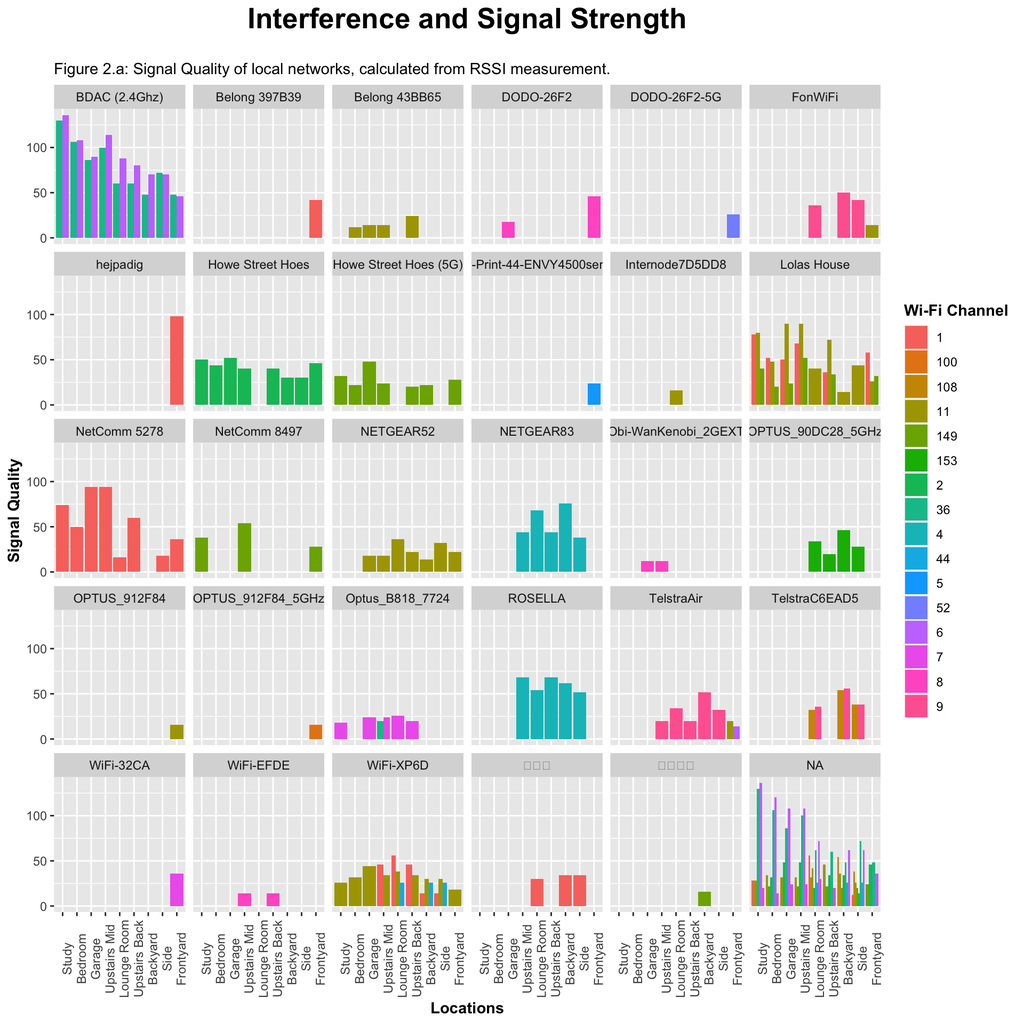

```r
wifi_scan %>%
  ggplot(mapping =aes(x=reorder(Location, -RSSI, mean), y=2*(100+RSSI), fill = Channel)) +
  facet_wrap(~Network.Name) +
  geom_bar(position = "dodge", stat = "identity") +
  theme(axis.text.x = element_text(angle = 90)) +
  labs(title = "Interference and Signal Strength", subtitle = "Figure 2.a: Signal Quality of local networks, calculated from RSSI measurement.") +
  xlab("Locations") +
  scale_fill_discrete(name = "Wi-Fi Channel") +
  ylab("Signal Quality") +
  theme(plot.title = element_text(hjust = 0.5, margin = ggplot2::margin(b=20), face = "bold", size = 20), plot.caption = element_text(hjust = 0, size = 10, margin = ggplot2::margin(t=20)), axis.title = element_text(face = "bold"), legend.title = element_text(face = "bold"))
```

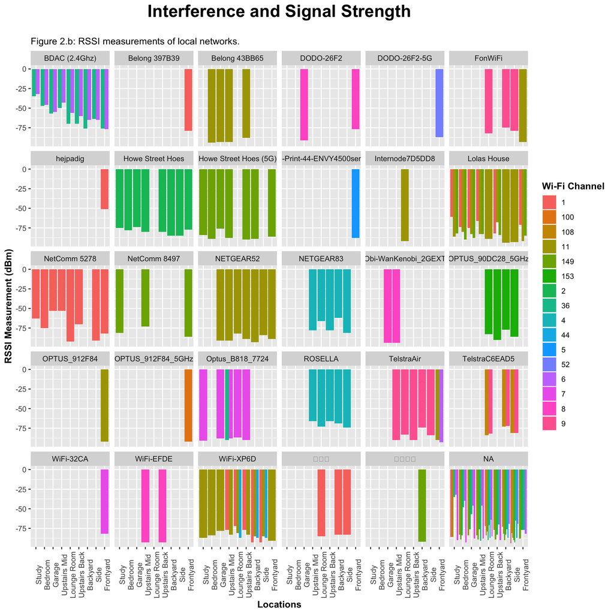

```r
wifi_scan %>%
  ggplot(mapping =aes(x=reorder(Location, -RSSI, mean), y=(RSSI), fill = Channel)) +
  facet_wrap(~Network.Name) +
  geom_bar(position = "dodge", stat = "identity") +
  theme(axis.text.x = element_text(angle = 90)) +
  labs(title = "Interference and Signal Strength", subtitle = "Figure 2.b: RSSI measurements of local networks.") +
  xlab("Locations") +
  scale_fill_discrete(name = "Wi-Fi Channel") +
  ylab("RSSI Measurement (dBm)") +
  theme(plot.title = element_text(hjust = 0.5, margin = ggplot2::margin(b=20), face = "bold", size = 20), plot.caption = element_text(hjust = 0, size = 10, margin = ggplot2::margin(t=20)), axis.title = element_text(face = "bold"), legend.title = element_text(face = "bold"))
```

There is very obvious signal attenuation across the networks studied in this report. Understanding the materials located at the location of each scan allows for better understanding of the RSSI measurements of each network, and can be used to easily infer which channels are likely to be occupied by 5Ghz band communications, and which are more likely to be 2.4Ghz channels.

For example, within the *Study* location we can interpret the interference difference between brick material versus air. Comparing the **BDAC (2.4Ghz)** and **Lolas House** networks there is significant difference in the Received Signal Strength Indicator (RSSI) score for both networks.

For **BDAC (2.4Ghz)** we notice two channels (Channel 36 and Channel 6) measuring RSSI scores of -35dBm and -32dBm which is near 100% signal strength. In this location there is a 2-metre air gap between the AP and the measurement location; this is the optimal baseline for the **BDAC (2.4Ghz)** network.

#### Coverage

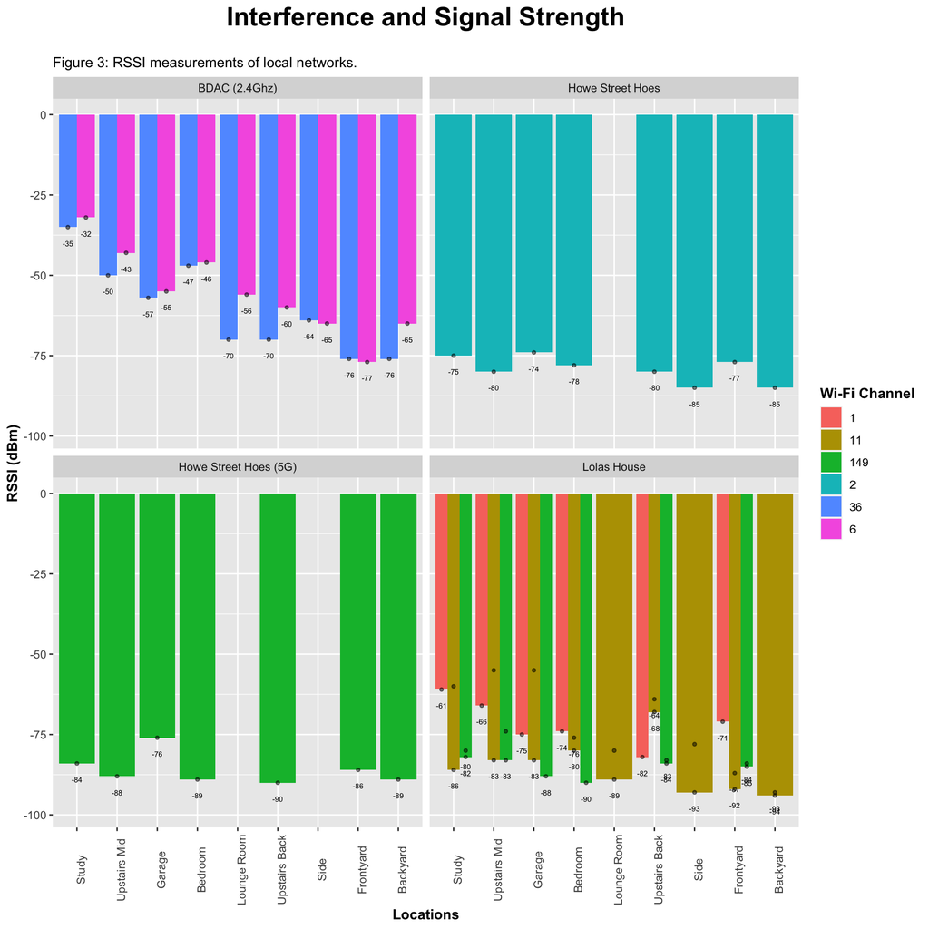

```r
wifi_scan %>% filter(Network.Name == "BDAC (2.4Ghz)" | Network.Name == "Lolas House" | Network.Name == "Howe Street Hoes" | Network.Name == "Howe Street Hoes (5G)") %>%
  ggplot(mapping =aes(x=reorder(Location, -RSSI, mean), y=(RSSI), fill = Channel)) +
  geom_text(aes(x=reorder(Location, -RSSI, mean), y= (RSSI-5), label = RSSI), position = position_dodge(width = 0.9), size = 2) +
  facet_wrap(~Network.Name) +
  geom_bar(position = "dodge", stat = "identity") +
  geom_point(aes(x=reorder(Location, -RSSI, mean), y= RSSI), position = position_dodge(width = 0.9), colour = "black", size = 1, alpha=0.5, show.legend = F) +
  theme(axis.text.x = element_text(angle = 90)) +
  labs(title = "Interference and Signal Strength", subtitle = "Figure 3: RSSI measurements of local networks.") +
  xlab("Locations") +
  scale_fill_discrete(name = "Wi-Fi Channel") +
  ylab("RSSI (dBm)") +
  theme(plot.title = element_text(hjust = 0.5, margin = ggplot2::margin(b=20), face = "bold", size = 20), plot.caption = element_text(hjust = 0, size = 10, margin = ggplot2::margin(t=20)), axis.title = element_text(face = "bold"), legend.title = element_text(face = "bold"))
```

For the **BDAC (2.4Ghz)** network the AP coverages a sufficient amount of the desired area, given the constraints of NBN coaxial port access. However, in the future a second AP may be obtained to cover weaker reception in the backyard area of the house - particularly for the higher frequency 5Ghz communications which would benefit the gaming and streaming devices in that area of the house.

The **Howe Street** network currently operates on the channel 149 80Mhz band which sees significant traffic from other networks, this network would benefit from changing to a less congested Wi-Fi channel. The 2.4Ghz channel sees sharper drops in signal strength in comparison to other local networks, this suggests poor indoor placement or quality of the AP. Furthermore, this network operates on only 2 Wi-Fi channels, this is low for an area that sees many networks broadcasting on between 4 - 6 Wi-Fi channels simultaneously. This again suggests a basic featured Access Point.

Lastly, **Lolas House** network performs well in the 2.4Ghz bands with average signal strength in most scanned locations. Notably, there appears to be better coverage in the *Upstairs Back* location and within another 2.4Ghz band channel (channel 11). This suggests the prescence of a WiFi repeater AP upstairs, which is reinfored by the prescence of channel 1 communications which is often used as a wireless mesh backhaul channel.

#### Speed Tests

```r
speedtests <- as.data.frame(rbind(
c("Study",11,20.58, 3.93),
c("Garage",10,19.67, 4.14),
c("Front",11,12.41, 2.54),
c("Bedroom",10,20.43, 3.96),
c("Side",11,3.83, 4.33),
c("Upstairs Mid",11,18.31, 4.09),
c("Upstairs Back",11,18.18, 3.64),
c("Loungeroom",11,18.08, 4.30),
c("Backyard",11,16.74, 4.01)
))
colnames(speedtests) <- c("Location", "Ping", "Download", "Upload")
speedtests$Location <- as.factor(speedtests$Location)
speedtests$Download <- as.numeric(speedtests$Download)
speedtests$Upload <- as.numeric(speedtests$Upload)
speedtests$Ping <- as.numeric(speedtests$Ping)

speedtests <- speedtests %>% gather("Type", "Value", 2:4)
speedtests$Type <- as.factor(speedtests$Type)
```

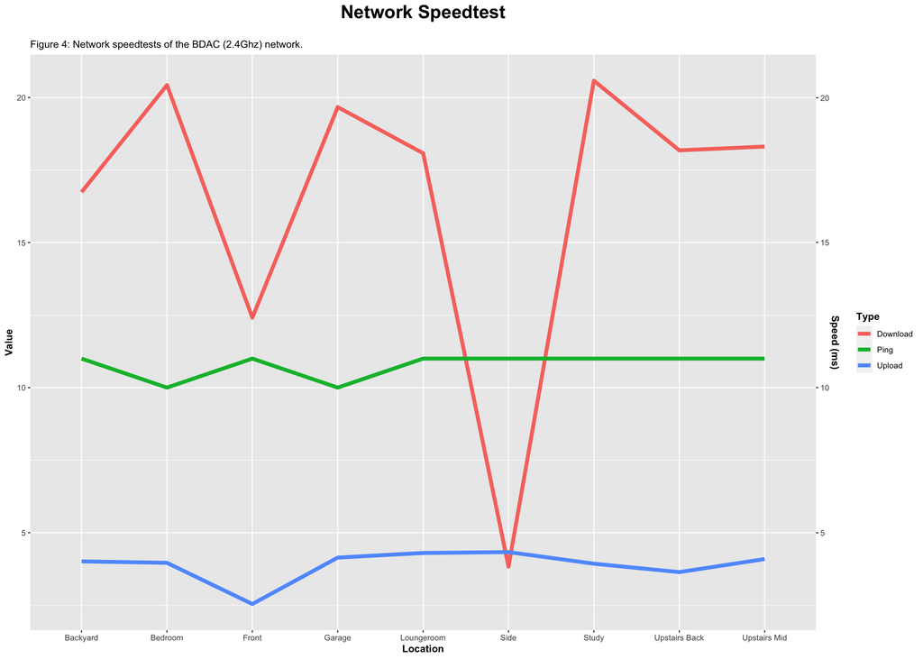

```r
ggplot(data=speedtests) +
    geom_line(aes(x=Location, y=Value, colour = Type, group = Type), size = 2) +
    scale_y_continuous(sec.axis = sec_axis((~.*1),name="Speed (ms)")) +
    labs(title = "Network Speedtest", subtitle = "Figure 4: Network speedtests of the BDAC (2.4Ghz) network.") +
    theme(plot.title = element_text(hjust = 0.5, margin = ggplot2::margin(b=20), face = "bold", size = 20), plot.caption = element_text(hjust = 0, size = 10, margin = ggplot2::margin(t=20)), axis.title = element_text(face = "bold"), legend.title = element_text(face = "bold"))
```

## Appendix: Tables

```r
library("kableExtra")
side[order(-side$RSSI),] %>% select(-Bytes, -Country, -Length, -PH, -SWAP, -hs20, -Airport) %>% kable(row.names = F, caption = "Table 1: Side") %>% kable_styling(bootstrap_options = c("striped", "hover", "condensed"), full_width = FALSE)%>% kableExtra::scroll_box(width = "100%")
```

Table 1: Side

| Network.Name | BSSID | Channel | Width | Type | RSSI | RSN.MCast | RSN.USCast | Auth | Caps | WPA | WEP | IBSS | Location |
| --- | --- | --- | --- | --- | --- | --- | --- | --- | --- | --- | --- | --- | --- |
| NA | e2:63:da:1c:03:91 | 36 | 80 | 11ac | -64 | NA | NA | no | no | no | no | no | Side |
| BDAC (2.4Ghz) | e0:63:da:1c:03:91 | 36 | 80 | 11ac | -64 | aes_ccm | aes_cm | psk | 0xc | NA | no | no | Side |
| NA | e6:63:da:1c:03:91 | 36 | 80 | 11ac | -65 | aes_ccm | aes_cm | psk | 0xc | NA | no | no | Side |
| NA | ee:63:da:1c:03:91 | 36 | 80 | 11ac | -65 | aes_ccm | aes_cm | psk | 0xc | NA | no | no | Side |
| BDAC (2.4Ghz) | e0:63:da:1b:03:91 | 6 | 20 | 11n | -65 | aes_ccm | aes_cm | psk | 0xc | NA | no | no | Side |
| NA | e6:63:da:1b:03:91 | 6 | 20 | 11n | -69 | aes_ccm | aes_cm | psk | 0xc | NA | no | no | Side |
| ROSELLA | 3c:37:86:62:99:a9 | 4 | 20 | 11n | -74 | aes_ccm | aes_cm | psk | 0xc | NA | no | no | Side |
| Lolas House | 70:3a:cb:92:ea:72 | 11 | 20 | 11n | -78 | aes_ccm | aes_cm | psk | 0xc | NA | no | no | Side |
| FonWiFi | a6:91:b1:c6:ea:d0 | 9 | 20 | 11n | -79 | NA | NA | no | no | no | no | no | Side |
| NA | a6:91:b1:c6:ea:df | 108 | 80 | 11ac | -81 | aes_ccm | aes_cm | psk | 0xc | NA | no | no | Side |
| NETGEAR83 | 9c:3d:cf:2d:4e:02 | 4 | 20 | 11n | -81 | aes_ccm | aes_cm | psk | 0x8c | NA | no | no | Side |
| TelstraC6EAD5 | a4:91:b1:c6:ea:d5 | 9 | 20 | 11n | -81 | aes_ccm | aes_cm | psk | 0xc | NA | no | no | Side |
| TelstraC6EAD5 | a6:91:b1:c6:ea:dd | 108 | 80 | 11ac | -81 | aes_ccm | aes_cm | psk | 0xc | NA | no | no | Side |
| 呀哈哈 | 78:65:59:4e:59:a0 | 1 | 20 | 11n | -83 | aes_ccm | aes_cm | psk | 0x8c | NA | no | no | Side |
| NETGEAR52 | 14:59:c0:a4:13:22 | 11 | 20 | 11n | -84 | aes_ccm | aes_cm | psk | 0x8c | NA | no | no | Side |
| TelstraAir | a6:91:b1:c6:ea:d7 | 9 | 20 | 11n | -84 | NA | NA | no | no | no | no | no | Side |
| Howe Street Hoes | d8:0d:17:49:ac:87 | 2 | 20 | 11n | -85 | tkip | aes_ccm tkip | psk | 0x0 | tkip | ccmp tkip | psk | Side |
| WiFi-XP6D | b4:fb:e4:f4:5b:01 | 11 | 20 | 11n | -85 | aes_ccm | aes_cm | psk | 0x0 | NA | no | no | Side |
| OPTUS_90DC28_5GHz | 3c:37:86:62:99:a8 | 153 | 80 | 11ac | -86 | aes_ccm | aes_cm | psk | 0xc | NA | no | no | Side |
| NA | b6:fb:e4:f4:5b:01 | 11 | 20 | 11n | -87 | aes_ccm | aes_cm | psk | 0x0 | NA | no | no | Side |
| NA | c6:fb:e4:f5:5b:01 | 44 | 40 | 11ac | -87 | aes_ccm | aes_cm | psk | 0x0 | NA | no | no | Side |
| WiFi-XP6D | b6:fb:e4:f5:5b:01 | 44 | 40 | 11ac | -87 | aes_ccm | aes_cm | psk | 0x0 | NA | no | no | Side |
| NA | fa:8f:ca:75:f3:71 | 149 | 20 | 11n | -90 | NA | NA | no | no | no | no | no | Side |
| NetComm 5278 | 18:f1:45:7c:6b:8e | 1 | 40 | 11n | -91 | aes_ccm | aes_cm | psk | 0xc | NA | no | no | Side |
| NA | ea:0d:17:49:ac:87 | 2 | 20 | 11n | -93 | aes_ccm | aes_cm | psk | 0x0 | NA | no | no | Side |
| Lolas House | 70:3a:cb:92:eb:b1 | 11 | 20 | 11n | -93 | aes_ccm | aes_cm | psk | 0xc | NA | no | no | Side |
| WiFi-XP6D | 18:e8:29:14:0a:9b | 1 | 20 | 11n | -93 | aes_ccm | aes_cm | psk | 0x0 | NA | no | no | Side |
| NA | 1a:e8:29:14:0a:9b | 1 | 20 | 11n | -94 | aes_ccm | aes_cm | psk | 0x0 | NA | no | no | Side |

```r
bedroom[order(-bedroom$RSSI),] %>% select(-Bytes, -Country, -Length, -PH, -SWAP, -hs20, -Airport) %>% kable(row.names = F, caption = "Table 2: Bedroom") %>% kable_styling(bootstrap_options = c("striped", "hover", "condensed"), full_width = FALSE)%>% kableExtra::scroll_box(width = "100%")
```

Table 2: Bedroom

| Network.Name | BSSID | Channel | Width | Type | RSSI | RSN.MCast | RSN.USCast | Auth | Caps | WPA | WEP | IBSS | Location |
| --- | --- | --- | --- | --- | --- | --- | --- | --- | --- | --- | --- | --- | --- |
| NA | e6:63:da:1b:03:91 | 6 | 20 | 11n | -40 | aes_ccm | aes_ccm | psk | 0xc | NA | no | no | Bedroom |
| BDAC (2.4Ghz) | e0:63:da:1b:03:91 | 6 | 20 | 11n | -46 | aes_ccm | aes_ccm | psk | 0xc | NA | no | no | Bedroom |
| NA | e2:63:da:1c:03:91 | 36 | 80 | 11ac | -47 | NA | NA | no | no | no | no | no | Bedroom |
| NA | e6:63:da:1c:03:91 | 36 | 80 | 11ac | -47 | aes_ccm | aes_ccm | psk | 0xc | NA | no | no | Bedroom |
| BDAC (2.4Ghz) | e0:63:da:1c:03:91 | 36 | 80 | 11ac | -47 | aes_ccm | aes_ccm | psk | 0xc | NA | no | no | Bedroom |
| NA | ea:63:da:1c:03:91 | 36 | 80 | 11ac | -48 | aes_ccm | aes_ccm | psk | 0xc | NA | no | no | Bedroom |
| NA | ee:63:da:1c:03:91 | 36 | 80 | 11ac | -48 | aes_ccm | aes_ccm | psk | 0xc | NA | no | no | Bedroom |
| Lolas House | 70:3a:cb:91:79:8f | 1 | 20 | 11n | -74 | aes_ccm | aes_ccm | psk | 0xc | NA | no | no | Bedroom |
| NetComm 5278 | 18:f1:45:7c:6b:8e | 1 | 40 | 11n | -75 | aes_ccm | aes_ccm | psk | 0xc | NA | no | no | Bedroom |
| Lolas House | 70:3a:cb:92:eb:b1 | 11 | 20 | 11n | -76 | aes_ccm | aes_ccm | psk | 0xc | NA | no | no | Bedroom |
| Howe Street Hoes | d8:0d:17:49:ac:87 | 2 | 20 | 11n | -78 | tkip | aes_ccm tkip | psk | 0x0 | tkip | ccmp tkip | psk | Bedroom |
| Lolas House | 70:3a:cb:92:ea:72 | 11 | 20 | 11n | -80 | aes_ccm | aes_ccm | psk | 0xc | NA | no | no | Bedroom |
| NA | b6:fb:e4:f4:5b:01 | 11 | 20 | 11n | -83 | aes_ccm | aes_ccm | psk | 0x0 | NA | no | no | Bedroom |
| NA | ea:0d:17:49:ac:87 | 2 | 20 | 11n | -84 | aes_ccm | aes_ccm | psk | 0x0 | NA | no | no | Bedroom |
| WiFi-XP6D | b4:fb:e4:f4:5b:01 | 11 | 20 | 11n | -84 | aes_ccm | aes_ccm | psk | 0x0 | NA | no | no | Bedroom |
| NA | ea:0d:17:49:ac:86 | 149 | 80 | 11ac | -89 | aes_ccm | aes_ccm | psk | 0x0 | NA | no | no | Bedroom |
| Howe Street Hoes (5G) | d8:0d:17:49:ac:86 | 149 | 80 | 11ac | -89 | tkip | aes_ccm tkip | psk | 0x0 | tkip | ccmp tkip | psk | Bedroom |
| Lolas House | 70:3a:cb:92:eb:ad | 149 | 80 | 11ac | -90 | aes_ccm | aes_ccm | psk | 0xc | NA | no | no | Bedroom |
| NA | c0:b5:cd:9f:77:28 | 7 | 20 | 11n | -93 | aes_ccm | aes_ccm | psk | 0xc | NA | no | no | Bedroom |
| Belong 43BB65 | 70:0b:01:43:bb:6b | 11 | 20 | 11n | -94 | aes_ccm | aes_ccm | psk | 0xc | NA | no | no | Bedroom |

```r
study[order(-study$RSSI),] %>% select(-Bytes, -Country, -Length, -PH, -SWAP, -hs20, -Airport) %>% kable(row.names = F, caption = "Table 3: Study") %>% kable_styling(bootstrap_options = c("striped", "hover", "condensed"), full_width = FALSE)%>% kableExtra::scroll_box(width = "100%")
```

Table 3: Study

| Network.Name | BSSID | Channel | Width | Type | RSSI | RSN.MCast | RSN.USCast | Auth | Caps | WPA | WEP | IBSS | Location |
| --- | --- | --- | --- | --- | --- | --- | --- | --- | --- | --- | --- | --- | --- |
| NA | e6:63:da:1b:03:91 | 6 | 20 | 11n | -32 | aes_ccm | aes_ccm | psk | 0xc | NA | no | no | Study |
| BDAC (2.4Ghz) | e0:63:da:1b:03:91 | 6 | 20 | 11n | -32 | aes_ccm | aes_ccm | psk | 0xc | NA | no | no | Study |
| NA | e2:63:da:1c:03:91 | 36 | 80 | 11ac | -35 | NA | NA | no | no | no | no | no | Study |
| NA | e6:63:da:1c:03:91 | 36 | 80 | 11ac | -35 | aes_ccm | aes_ccm | psk | 0xc | NA | no | no | Study |
| NA | ea:63:da:1c:03:91 | 36 | 80 | 11ac | -35 | aes_ccm | aes_ccm | psk | 0xc | NA | no | no | Study |
| NA | ee:63:da:1c:03:91 | 36 | 80 | 11ac | -35 | aes_ccm | aes_ccm | psk | 0xc | NA | no | no | Study |
| BDAC (2.4Ghz) | e0:63:da:1c:03:91 | 36 | 80 | 11ac | -35 | aes_ccm | aes_ccm | psk | 0xc | NA | no | no | Study |
| Lolas House | 70:3a:cb:92:eb:b1 | 11 | 20 | 11n | -60 | aes_ccm | aes_ccm | psk | 0xc | NA | no | no | Study |
| Lolas House | 70:3a:cb:91:79:8f | 1 | 20 | 11n | -61 | aes_ccm | aes_ccm | psk | 0xc | NA | no | no | Study |
| NetComm 5278 | 18:f1:45:7c:6b:8e | 1 | 40 | 11n | -63 | aes_ccm | aes_ccm | psk | 0xc | NA | no | no | Study |
| Howe Street Hoes | d8:0d:17:49:ac:87 | 2 | 20 | 11n | -75 | tkip | aes_ccm tkip | psk | 0x0 | tkip | ccmp tkip | psk | Study |
| Lolas House | 70:3a:cb:92:eb:ad | 149 | 80 | 11ac | -80 | aes_ccm | aes_ccm | psk | 0xc | NA | no | no | Study |
| NetComm 8497 | 18:f1:45:7c:6b:8d | 149 | 80 | 11ac | -81 | aes_ccm | aes_ccm | psk | 0xc | NA | no | no | Study |
| Lolas House | 70:3a:cb:91:79:8b | 149 | 80 | 11ac | -82 | aes_ccm | aes_ccm | psk | 0xc | NA | no | no | Study |
| Howe Street Hoes (5G) | d8:0d:17:49:ac:86 | 149 | 80 | 11ac | -84 | tkip | aes_ccm tkip | psk | 0x0 | tkip | ccmp tkip | psk | Study |
| NA | 1a:e8:29:14:0a:9b | 1 | 20 | 11n | -86 | aes_ccm | aes_ccm | psk | 0x0 | NA | no | no | Study |
| NA | b6:fb:e4:f4:5b:01 | 11 | 20 | 11n | -86 | aes_ccm | aes_ccm | psk | 0x0 | NA | no | no | Study |
| Lolas House | 70:3a:cb:92:ea:72 | 11 | 20 | 11n | -86 | aes_ccm | aes_ccm | psk | 0xc | NA | no | no | Study |
| WiFi-XP6D | b4:fb:e4:f4:5b:01 | 11 | 20 | 11n | -87 | aes_ccm | aes_ccm | psk | 0x0 | NA | no | no | Study |
| NA | c0:b5:cd:9f:77:28 | 7 | 20 | 11n | -90 | aes_ccm | aes_ccm | psk | 0xc | NA | no | no | Study |
| Optus_B818_7724 | c0:b5:cd:9f:77:24 | 7 | 20 | 11n | -91 | aes_ccm | aes_ccm | psk | 0xc | NA | no | no | Study |

```r
front[order(-front$RSSI),] %>% select(-Bytes, -Country, -Length, -PH, -SWAP, -hs20, -Airport) %>% kable(row.names = F, caption = "Table 4: Frontyard") %>% kable_styling(bootstrap_options = c("striped", "hover", "condensed"), full_width = FALSE)%>% kableExtra::scroll_box(width = "100%")
```

Table 4: Frontyard

| Network.Name | BSSID | Channel | Width | Type | RSSI | RSN.MCast | RSN.USCast | Auth | Caps | WPA | WEP | IBSS | Location |
| --- | --- | --- | --- | --- | --- | --- | --- | --- | --- | --- | --- | --- | --- |
| hejpadig | 18:90:d8:80:44:51 | 1 | 20 | 11n | -51 | tkip | aes_ccm tkip | psk | 0xc | tkip | ccmp tkip | psk | Frontyard |
| Lolas House | 70:3a:cb:91:79:8f | 1 | 20 | 11n | -71 | aes_ccm | aes_ccm | psk | 0xc | NA | no | no | Frontyard |
| NA | ee:63:da:1c:03:91 | 36 | 80 | 11ac | -76 | aes_ccm | aes_ccm | psk | 0xc | NA | no | no | Frontyard |
| BDAC (2.4Ghz) | e0:63:da:1c:03:91 | 36 | 80 | 11ac | -76 | aes_ccm | aes_ccm | psk | 0xc | NA | no | no | Frontyard |
| NA | e2:63:da:1c:03:91 | 36 | 80 | 11ac | -77 | NA | NA | no | no | no | no | no | Frontyard |
| NA | e6:63:da:1c:03:91 | 36 | 80 | 11ac | -77 | aes_ccm | aes_ccm | psk | 0xc | NA | no | no | Frontyard |
| NA | ea:0d:17:49:ac:87 | 2 | 20 | 11n | -77 | aes_ccm | aes_ccm | psk | 0x0 | NA | no | no | Frontyard |
| NA | ea:63:da:1c:03:91 | 36 | 80 | 11ac | -77 | aes_ccm | aes_ccm | psk | 0xc | NA | no | no | Frontyard |
| BDAC (2.4Ghz) | e0:63:da:1b:03:91 | 6 | 20 | 11n | -77 | aes_ccm | aes_ccm | psk | 0xc | NA | no | no | Frontyard |
| DODO-26F2 | 1c:59:9b:d1:26:f8 | 8 | 20 | 11n | -77 | aes_ccm | aes_ccm | psk | 0xc | ccmp | ccmp | psk | Frontyard |
| Howe Street Hoes | d8:0d:17:49:ac:87 | 2 | 20 | 11n | -77 | tkip | aes_ccm tkip | psk | 0x0 | tkip | ccmp tkip | psk | Frontyard |
| Belong 397B39 | d8:a7:56:39:7b:3f | 1 | 20 | 11n | -79 | aes_ccm | aes_ccm | psk | 0xc | NA | no | no | Frontyard |
| NA | e6:63:da:1b:03:91 | 6 | 20 | 11n | -82 | aes_ccm | aes_ccm | psk | 0xc | NA | no | no | Frontyard |
| NetComm 5278 | 18:f1:45:7c:6b:8e | 1 | 40 | 11n | -82 | aes_ccm | aes_ccm | psk | 0xc | NA | no | no | Frontyard |
| WiFi-32CA | 74:da:88:cb:32:ca | 7 | 20 | 11n | -82 | aes_ccm | aes_ccm | psk | 0xc | NA | no | no | Frontyard |
| Lolas House | 70:3a:cb:92:eb:ad | 149 | 80 | 11ac | -84 | aes_ccm | aes_ccm | psk | 0xc | NA | no | no | Frontyard |
| Lolas House | 70:3a:cb:91:79:8b | 149 | 80 | 11ac | -85 | aes_ccm | aes_ccm | psk | 0xc | NA | no | no | Frontyard |
| Howe Street Hoes (5G) | d8:0d:17:49:ac:86 | 149 | 80 | 11ac | -86 | tkip | aes_ccm tkip | psk | 0x0 | tkip | ccmp tkip | psk | Frontyard |
| NetComm 8497 | 18:f1:45:7c:6b:8d | 149 | 80 | 11ac | -86 | aes_ccm | aes_ccm | psk | 0xc | NA | no | no | Frontyard |
| DODO-26F2-5G | 1c:59:9b:d1:26:fc | 52 | 80 | 11ac | -87 | aes_ccm | aes_ccm | psk | 0xc | ccmp | ccmp | psk | Frontyard |
| Lolas House | 70:3a:cb:92:eb:b1 | 11 | 20 | 11n | -87 | aes_ccm | aes_ccm | psk | 0xc | NA | no | no | Frontyard |
| NA | ea:0d:17:49:ac:86 | 149 | 80 | 11ac | -88 | aes_ccm | aes_ccm | psk | 0x0 | NA | no | no | Frontyard |
| HP-Print-44-ENVY4500series | 50:65:f3:fe:ec:44 | 5 | 20 | 11g | -88 | aes_ccm | aes_ccm | psk | 0x0 | NA | no | no | Frontyard |
| NETGEAR52 | 14:59:c0:a4:13:22 | 11 | 20 | 11n | -89 | aes_ccm | aes_ccm | psk | 0x8c | NA | no | no | Frontyard |
| TelstraAir | 92:30:d9:df:7b:1e | 11 | 40 | 11n | -90 | NA | NA | no | no | no | no | no | Frontyard |
| WiFi-XP6D | b4:fb:e4:f4:5b:01 | 11 | 20 | 11n | -91 | aes_ccm | aes_ccm | psk | 0x0 | NA | no | no | Frontyard |
| Lolas House | 70:3a:cb:92:ea:72 | 11 | 20 | 11n | -92 | aes_ccm | aes_ccm | psk | 0xc | NA | no | no | Frontyard |
| OPTUS_912F84 | b8:ee:0e:91:2f:85 | 11 | 20 | 11n | -92 | aes_ccm | aes_ccm | psk | 0xc | NA | no | no | Frontyard |
| OPTUS_912F84_5GHz | b8:ee:0e:91:2f:86 | 100 | 80 | 11ac | -92 | aes_ccm | aes_ccm | psk | 0xc | NA | no | no | Frontyard |
| FonWiFi | 92:30:d9:df:7b:1f | 11 | 40 | 11n | -93 | NA | NA | no | no | no | no | no | Frontyard |
| TelstraAir | a6:91:b1:c5:ce:a9 | 6 | 20 | 11n | -93 | NA | NA | no | no | no | no | no | Frontyard |

```r
lounge_room[order(-lounge_room$RSSI),] %>% select(-Bytes, -Country, -Length, -PH, -SWAP, -hs20, -Airport) %>% kable(row.names = F, caption = "Table 5: Lounge Room") %>% kable_styling(bootstrap_options = c("striped", "hover", "condensed"), full_width = FALSE)%>% kableExtra::scroll_box(width = "100%")
```

Table 5: Lounge Room

| Network.Name | BSSID | Channel | Width | Type | RSSI | RSN.MCast | RSN.USCast | Auth | Caps | WPA | WEP | IBSS | Location |
| --- | --- | --- | --- | --- | --- | --- | --- | --- | --- | --- | --- | --- | --- |
| BDAC (2.4Ghz) | e0:63:da:1b:03:91 | 6 | 20 | 11n | -56 | aes_ccm | aes_ccm | psk | 0xc | NA | no | no | Lounge Room |
| NA | e6:63:da:1b:03:91 | 6 | 20 | 11n | -64 | aes_ccm | aes_ccm | psk | 0xc | NA | no | no | Lounge Room |
| NETGEAR83 | 9c:3d:cf:2d:4e:02 | 4 | 20 | 11n | -66 | aes_ccm | aes_ccm | psk | 0x8c | NA | no | no | Lounge Room |
| NA | e2:63:da:1c:03:91 | 36 | 80 | 11ac | -69 | NA | NA | no | no | no | no | no | Lounge Room |
| NA | e6:63:da:1c:03:91 | 36 | 80 | 11ac | -70 | aes_ccm | aes_ccm | psk | 0xc | NA | no | no | Lounge Room |
| BDAC (2.4Ghz) | e0:63:da:1c:03:91 | 36 | 80 | 11ac | -70 | aes_ccm | aes_ccm | psk | 0xc | NA | no | no | Lounge Room |
| NA | ee:63:da:1c:03:91 | 36 | 80 | 11ac | -71 | aes_ccm | aes_ccm | psk | 0xc | NA | no | no | Lounge Room |
| NA | 1a:e8:29:14:0a:9b | 1 | 20 | 11n | -72 | aes_ccm | aes_ccm | psk | 0x0 | NA | no | no | Lounge Room |
| WiFi-XP6D | 18:e8:29:14:0a:9b | 1 | 20 | 11n | -72 | aes_ccm | aes_ccm | psk | 0x0 | NA | no | no | Lounge Room |
| ROSELLA | 3c:37:86:62:99:a9 | 4 | 20 | 11n | -73 | aes_ccm | aes_ccm | psk | 0xc | NA | no | no | Lounge Room |
| NA | b6:fb:e4:f4:5b:01 | 11 | 20 | 11n | -79 | aes_ccm | aes_ccm | psk | 0x0 | NA | no | no | Lounge Room |
| Lolas House | 70:3a:cb:92:ea:72 | 11 | 20 | 11n | -80 | aes_ccm | aes_ccm | psk | 0xc | NA | no | no | Lounge Room |
| WiFi-XP6D | b4:fb:e4:f4:5b:01 | 11 | 20 | 11n | -81 | aes_ccm | aes_ccm | psk | 0x0 | NA | no | no | Lounge Room |
| FonWiFi | a6:91:b1:c6:ea:d0 | 9 | 20 | 11n | -82 | NA | NA | no | no | no | no | no | Lounge Room |
| NETGEAR52 | 14:59:c0:a4:13:22 | 11 | 20 | 11n | -82 | aes_ccm | aes_ccm | psk | 0x8c | NA | no | no | Lounge Room |
| TelstraC6EAD5 | a4:91:b1:c6:ea:d5 | 9 | 20 | 11n | -82 | aes_ccm | aes_ccm | psk | 0xc | NA | no | no | Lounge Room |
| OPTUS_90DC28_5GHz | 3c:37:86:62:99:a8 | 153 | 80 | 11ac | -83 | aes_ccm | aes_ccm | psk | 0xc | NA | no | no | Lounge Room |
| TelstraAir | a6:91:b1:c6:ea:d7 | 9 | 20 | 11n | -83 | NA | NA | no | no | no | no | no | Lounge Room |
| NA | a6:91:b1:c6:ea:df | 108 | 80 | 11ac | -84 | aes_ccm | aes_ccm | psk | 0xc | NA | no | no | Lounge Room |
| TelstraC6EAD5 | a6:91:b1:c6:ea:dd | 108 | 80 | 11ac | -84 | aes_ccm | aes_ccm | psk | 0xc | NA | no | no | Lounge Room |
| NA | c0:b5:cd:9f:77:28 | 7 | 20 | 11n | -85 | aes_ccm | aes_ccm | psk | 0xc | NA | no | no | Lounge Room |
| 呀哈哈 | 78:65:59:4e:59:a0 | 1 | 20 | 11n | -85 | aes_ccm | aes_ccm | psk | 0x8c | NA | no | no | Lounge Room |
| NA | 2a:e8:29:15:0a:9b | 44 | 40 | 11ac | -87 | aes_ccm | aes_ccm | psk | 0x0 | NA | no | no | Lounge Room |
| Optus_B818_7724 | c0:b5:cd:9f:77:24 | 7 | 20 | 11n | -87 | aes_ccm | aes_ccm | psk | 0xc | NA | no | no | Lounge Room |
| WiFi-XP6D | 1a:e8:29:15:0a:9b | 44 | 40 | 11ac | -87 | aes_ccm | aes_ccm | psk | 0x0 | NA | no | no | Lounge Room |
| Lolas House | 70:3a:cb:92:eb:b1 | 11 | 20 | 11n | -89 | aes_ccm | aes_ccm | psk | 0xc | NA | no | no | Lounge Room |
| NA | ea:0d:17:49:ac:87 | 2 | 20 | 11n | -90 | aes_ccm | aes_ccm | psk | 0x0 | NA | no | no | Lounge Room |
| Internode7D5DD8 | a4:91:b1:7d:5d:d8 | 11 | 20 | 11n | -92 | aes_ccm | aes_ccm | psk | 0xc | NA | no | no | Lounge Room |
| NetComm 5278 | 18:f1:45:7c:6b:8e | 1 | 40 | 11n | -92 | aes_ccm | aes_ccm | psk | 0xc | NA | no | no | Lounge Room |

```r
garage[order(-garage$RSSI),] %>% select(-Bytes, -Country, -Length, -PH, -SWAP, -hs20, -Airport) %>% kable(row.names = F, caption = "Table 6: Garage") %>% kable_styling(bootstrap_options = c("striped", "hover", "condensed"), full_width = FALSE)%>% kableExtra::scroll_box(width = "100%")
```

Table 6: Garage

| Network.Name | BSSID | Channel | Width | Type | RSSI | RSN.MCast | RSN.USCast | Auth | Caps | WPA | WEP | IBSS | Location |
| --- | --- | --- | --- | --- | --- | --- | --- | --- | --- | --- | --- | --- | --- |
| NA | e6:63:da:1b:03:91 | 6 | 20 | 11n | -46 | aes_ccm | aes_ccm | psk | 0xc | NA | no | no | Garage |
| NetComm 5278 | 18:f1:45:7c:6b:8e | 1 | 40 | 11n | -53 | aes_ccm | aes_ccm | psk | 0xc | NA | no | no | Garage |
| BDAC (2.4Ghz) | e0:63:da:1b:03:91 | 6 | 20 | 11n | -55 | aes_ccm | aes_ccm | psk | 0xc | NA | no | no | Garage |
| Lolas House | 70:3a:cb:92:eb:b1 | 11 | 20 | 11n | -55 | aes_ccm | aes_ccm | psk | 0xc | NA | no | no | Garage |
| NA | e2:63:da:1c:03:91 | 36 | 80 | 11ac | -57 | NA | NA | no | no | no | no | no | Garage |
| NA | e6:63:da:1c:03:91 | 36 | 80 | 11ac | -57 | aes_ccm | aes_ccm | psk | 0xc | NA | no | no | Garage |
| BDAC (2.4Ghz) | e0:63:da:1c:03:91 | 36 | 80 | 11ac | -57 | aes_ccm | aes_ccm | psk | 0xc | NA | no | no | Garage |
| Howe Street Hoes | d8:0d:17:49:ac:87 | 2 | 20 | 11n | -74 | tkip | {aes_ccmtkip | psk | 0x0 | tkip | ccmp tkip | psk | Garage |
| Lolas House | 70:3a:cb:91:79:8f | 1 | 20 | 11n | -75 | aes_ccm | aes_ccm | psk | 0xc | NA | no | no | Garage |
| NA | ea:0d:17:49:ac:87 | 2 | 20 | 11n | -76 | aes_ccm | aes_ccm | psk | 0x0 | NA | no | no | Garage |
| Howe Street Hoes (5G) | d8:0d:17:49:ac:86 | 149 | 80 | 11ac | -76 | tkip | {aes_ccmtkip | psk | 0x0 | tkip | ccmp tkip | psk | Garage |
| WiFi-XP6D | b4:fb:e4:f4:5b:01 | 11 | 20 | 11n | -78 | aes_ccm | aes_ccm | psk | 0x0 | NA | no | no | Garage |
| Lolas House | 70:3a:cb:92:ea:72 | 11 | 20 | 11n | -83 | aes_ccm | aes_ccm | psk | 0xc | NA | no | no | Garage |
| NA | b6:fb:e4:f4:5b:01 | 11 | 20 | 11n | -84 | aes_ccm | aes_ccm | psk | 0x0 | NA | no | no | Garage |
| NA | c0:b5:cd:9f:77:28 | 7 | 20 | 11n | -88 | aes_ccm | aes_ccm | psk | 0xc | NA | no | no | Garage |
| Lolas House | 70:3a:cb:91:79:8b | 149 | 80 | 11ac | -88 | aes_ccm | aes_ccm | psk | 0xc | NA | no | no | Garage |
| Optus_B818_7724 | c0:b5:cd:9f:77:24 | 7 | 20 | 11n | -88 | aes_ccm | aes_ccm | psk | 0xc | NA | no | no | Garage |
| DODO-26F2 | 1c:59:9b:d1:26:f8 | 8 | 20 | 11n | -91 | aes_ccm | aes_ccm | psk | 0xc | ccmp | ccmp | psk | Garage |
| NETGEAR52 | 14:59:c0:a4:13:22 | 11 | 20 | 11n | -91 | aes_ccm | aes_ccm | psk | 0x8c | NA | no | no | Garage |
| Belong 43BB65 | 70:0b:01:43:bb:6b | 11 | 20 | 11n | -93 | aes_ccm | aes_ccm | psk | 0xc | NA | no | no | Garage |
| Obi-WanKenobi_2GEXT | 8c:3b:ad:bd:54:e7 | 8 | 20 | 11ac | -94 | aes_ccm | aes_ccm | psk | 0x0 | NA | no | no | Garage |

```r
backyard[order(-backyard$RSSI),] %>% select(-Bytes, -Country, -Length, -PH, -SWAP, -hs20, -Airport) %>% kable(row.names = F, caption = "Table 7: Backyard") %>% kable_styling(bootstrap_options = c("striped", "hover", "condensed"), full_width = FALSE)%>% kableExtra::scroll_box(width = "100%")
```

Table 7: Backyard

| Network.Name | BSSID | Channel | Width | Type | RSSI | RSN.MCast | RSN.USCast | Auth | Caps | WPA | WEP | IBSS | Location |
| --- | --- | --- | --- | --- | --- | --- | --- | --- | --- | --- | --- | --- | --- |
| NETGEAR83 | 9c:3d:cf:2d:4e:02 | 4 | 20 | 11n | -62 | aes_ccm | aes_ccm | psk | 140 | NA | no | no | Backyard |
| BDAC (2.4Ghz) | e0:63:da:1b:03:91 | 6 | 20 | 11n | -65 | aes_ccm | aes_ccm | psk | 12 | NA | no | no | Backyard |
| NA | e6:63:da:1b:03:91 | 6 | 20 | 11n | -69 | aes_ccm | aes_ccm | psk | 12 | NA | no | no | Backyard |
| ROSELLA | 3c:37:86:62:99:a9 | 4 | 20 | 11n | -69 | aes_ccm | aes_ccm | psk | 12 | NA | no | no | Backyard |
| TelstraC6EAD5 | a4:91:b1:c6:ea:d5 | 9 | 20 | 11n | -72 | aes_ccm | aes_ccm | psk | 12 | NA | no | no | Backyard |
| NA | a6:91:b1:c6:ea:df | 108 | 80 | 11ac | -73 | aes_ccm | aes_ccm | psk | 12 | NA | no | no | Backyard |
| TelstraC6EAD5 | a6:91:b1:c6:ea:dd | 108 | 80 | 11ac | -73 | aes_ccm | aes_ccm | psk | 12 | NA | no | no | Backyard |
| TelstraAir | a6:91:b1:c6:ea:d7 | 9 | 20 | 11n | -74 | aes_ccmp | tkip | NA | NA | NA | no | no | Backyard |
| FonWiFi | a6:91:b1:c6:ea:d0 | 9 | 20 | 11n | -75 | aes_ccmp | tkip | NA | NA | NA | no | no | Backyard |
| NA | e2:63:da:1c:03:91 | 36 | 80 | 11ac | -76 | aes_ccmp | tkip | NA | NA | NA | no | no | Backyard |
| NA | e6:63:da:1c:03:91 | 36 | 80 | 11ac | -76 | aes_ccm | aes_ccm | psk | 12 | NA | no | no | Backyard |
| NA | ea:63:da:1c:03:91 | 36 | 80 | 11ac | -76 | aes_ccm | aes_ccm | psk | 12 | NA | no | no | Backyard |
| NA | ee:63:da:1c:03:91 | 36 | 80 | 11ac | -76 | aes_ccm | aes_ccm | psk | 12 | NA | no | no | Backyard |
| BDAC (2.4Ghz) | e0:63:da:1c:03:91 | 36 | 80 | 11ac | -76 | aes_ccm | aes_ccm | psk | 12 | NA | no | no | Backyard |
| OPTUS_90DC28_5GHz | 3c:37:86:62:99:a8 | 153 | 80 | 11ac | -77 | aes_ccm | aes_ccm | psk | 12 | NA | no | no | Backyard |
| NA | b6:fb:e4:f4:5b:01 | 11 | 20 | 11n | -82 | aes_ccm | aes_ccm | psk | 0 | NA | no | no | Backyard |
| NA | ea:0d:17:49:ac:87 | 2 | 20 | 11n | -83 | aes_ccm | aes_ccm | psk | 0 | NA | no | no | Backyard |
| 呀哈哈 | 78:65:59:4e:59:a0 | 1 | 20 | 11n | -83 | aes_ccm | aes_ccm | psk | 140 | NA | no | no | Backyard |
| Howe Street Hoes | d8:0d:17:49:ac:87 | 2 | 20 | 11n | -85 | tkip | aes_ccmp tkip | psk | 0 | tkip | ccmp tkip | psk | Backyard |
| WiFi-XP6D | b4:fb:e4:f4:5b:01 | 11 | 20 | 11n | -85 | aes_ccm | aes_ccm | psk | 0 | NA | no | no | Backyard |
| NA | c6:fb:e4:f5:5b:01 | 44 | 40 | 11ac | -87 | aes_ccm | aes_ccm | psk | 0 | NA | no | no | Backyard |
| WiFi-XP6D | b6:fb:e4:f5:5b:01 | 44 | 40 | 11ac | -87 | aes_ccm | aes_ccm | psk | 0 | NA | no | no | Backyard |
| Howe Street Hoes (5G) | d8:0d:17:49:ac:86 | 149 | 80 | 11ac | -89 | tkip | aes_ccmp tkip | psk | 0 | tkip | ccmp tkip | psk | Backyard |
| NA | ea:0d:17:49:ac:86 | 149 | 80 | 11ac | -90 | aes_ccm | aes_ccm | psk | 0 | NA | no | no | Backyard |
| NA | fa:8f:ca:75:f3:71 | 149 | 20 | 11n | -90 | aes_ccmp | tkip | NA | NA | NA | no | no | Backyard |
| 让我康康 | 78:65:59:4e:59:a1 | 149 | 80 | 11ac | -92 | aes_ccm | aes_ccm | psk | 140 | NA | no | no | Backyard |
| Lolas House | 70:3a:cb:92:eb:b1 | 11 | 20 | 11n | -93 | aes_ccm | aes_ccm | psk | 12 | NA | no | no | Backyard |
| NETGEAR52 | 14:59:c0:a4:13:22 | 11 | 20 | 11n | -93 | aes_ccm | aes_ccm | psk | 140 | NA | no | no | Backyard |
| WiFi-XP6D | 18:e8:29:14:0a:9b | 1 | 20 | 11n | -93 | aes_ccm | aes_ccm | psk | 0 | NA | no | no | Backyard |
| Lolas House | 70:3a:cb:92:ea:72 | 11 | 20 | 11n | -94 | aes_ccm | aes_ccm | psk | 12 | NA | no | no | Backyard |

```r
upstairs_mid[order(-upstairs_mid$RSSI),] %>% select(-Bytes, -Country, -Length, -PH, -SWAP, -hs20, -Airport) %>% kable(row.names = F, caption = "Table 8: Upstairs Mid") %>% kable_styling(bootstrap_options = c("striped", "hover", "condensed"), full_width = FALSE)%>% kableExtra::scroll_box(width = "100%")
```

Table 8: Upstairs Mid

| Network.Name | BSSID | Channel | Width | Type | RSSI | RSN.MCast | RSN.USCast | Auth | Caps | WPA | WEP | IBSS | Location |
| --- | --- | --- | --- | --- | --- | --- | --- | --- | --- | --- | --- | --- | --- |
| BDAC (2.4Ghz) | e0:63:da:1b:03:91 | 6 | 20 | 11n | -43 | aes_ccm | aes_ccm | psk | 0xc | NA | no | no | Upstairs Mid |
| NA | e6:63:da:1b:03:91 | 6 | 20 | 11n | -46 | aes_ccm | aes_ccm | psk | 0xc | NA | no | no | Upstairs Mid |
| NA | ea:63:da:1c:03:91 | 36 | 80 | 11ac | -50 | aes_ccm | aes_ccm | psk | 0xc | NA | no | no | Upstairs Mid |
| NA | ee:63:da:1c:03:91 | 36 | 80 | 11ac | -50 | aes_ccm | aes_ccm | psk | 0xc | NA | no | no | Upstairs Mid |
| BDAC (2.4Ghz) | e0:63:da:1c:03:91 | 36 | 80 | 11ac | -50 | aes_ccm | aes_ccm | psk | 0xc | NA | no | no | Upstairs Mid |
| NetComm 5278 | 18:f1:45:7c:6b:8e | 1 | 40 | 11n | -53 | aes_ccm | aes_ccm | psk | 0xc | NA | no | no | Upstairs Mid |
| Lolas House | 70:3a:cb:92:eb:b1 | 11 | 20 | 11n | -55 | aes_ccm | aes_ccm | psk | 0xc | NA | no | no | Upstairs Mid |
| Lolas House | 70:3a:cb:91:79:8f | 1 | 20 | 11n | -66 | aes_ccm | aes_ccm | psk | 0xc | NA | no | no | Upstairs Mid |
| ROSELLA | 3c:37:86:62:99:a9 | 4 | 20 | 11n | -66 | aes_ccm | aes_ccm | psk | 0xc | NA | no | no | Upstairs Mid |
| NetComm 8497 | 18:f1:45:7c:6b:8d | 149 | 80 | 11ac | -73 | aes_ccm | aes_ccm | psk | 0xc | NA | no | no | Upstairs Mid |
| Lolas House | 70:3a:cb:92:eb:ad | 149 | 80 | 11ac | -74 | aes_ccm | aes_ccm | psk | 0xc | NA | no | no | Upstairs Mid |
| NA | ea:0d:17:49:ac:87 | 2 | 20 | 11n | -76 | aes_ccm | aes_ccm | psk | 0x0 | NA | no | no | Upstairs Mid |
| WiFi-XP6D | 18:e8:29:14:0a:9b | 1 | 20 | 11n | -77 | aes_ccm | aes_ccm | psk | 0x0 | NA | no | no | Upstairs Mid |
| NETGEAR83 | 9c:3d:cf:2d:4e:02 | 4 | 20 | 11n | -78 | aes_ccm | aes_ccm | psk | 0x8c | NA | no | no | Upstairs Mid |
| Howe Street Hoes | d8:0d:17:49:ac:87 | 2 | 20 | 11n | -80 | tkip | aes_ccm tkip | psk | 0x0 | tkip | ccmp tkip | psk | Upstairs Mid |
| Lolas House | 70:3a:cb:91:79:8b | 149 | 80 | 11ac | -83 | aes_ccm | aes_ccm | psk | 0xc | NA | no | no | Upstairs Mid |
| Lolas House | 70:3a:cb:92:ea:72 | 11 | 20 | 11n | -83 | aes_ccm | aes_ccm | psk | 0xc | NA | no | no | Upstairs Mid |
| WiFi-XP6D | b4:fb:e4:f4:5b:01 | 11 | 20 | 11n | -83 | aes_ccm | aes_ccm | psk | 0x0 | NA | no | no | Upstairs Mid |
| NA | b6:fb:e4:f4:5b:01 | 11 | 20 | 11n | -84 | aes_ccm | aes_ccm | psk | 0x0 | NA | no | no | Upstairs Mid |
| NA | c0:b5:cd:9f:77:28 | 7 | 20 | 11n | -88 | aes_ccm | aes_ccm | psk | 0xc | NA | no | no | Upstairs Mid |
| Howe Street Hoes (5G) | d8:0d:17:49:ac:86 | 149 | 80 | 11ac | -88 | tkip | aes_ccm tkip | psk | 0x0 | tkip | ccmp tkip | psk | Upstairs Mid |
| Optus_B818_7724 | c0:b5:cd:9f:77:24 | 7 | 20 | 11n | -88 | aes_ccm | aes_ccm | psk | 0xc | NA | no | no | Upstairs Mid |
| NA | ea:0d:17:49:ac:86 | 149 | 80 | 11ac | -89 | aes_ccm | aes_ccm | psk | 0x0 | NA | no | no | Upstairs Mid |
| Optus_B818_7724 | c0:b5:cd:9f:77:29 | 36 | 80 | 11ac | -90 | aes_ccm | aes_ccm | psk | 0x8c | NA | no | no | Upstairs Mid |
| TelstraAir | a6:91:b1:c6:ea:d7 | 9 | 20 | 11n | -90 | NA | NA | no | no | no | no | no | Upstairs Mid |
| NA | c0:b5:cd:9f:77:2b | 36 | 80 | 11ac | -91 | aes_ccm | aes_ccm | psk | 0x8c | NA | no | no | Upstairs Mid |
| NETGEAR52 | 14:59:c0:a4:13:22 | 11 | 20 | 11n | -91 | aes_ccm | aes_ccm | psk | 0x8c | NA | no | no | Upstairs Mid |
| Belong 43BB65 | 70:0b:01:43:bb:6b | 11 | 20 | 11n | -93 | aes_ccm | aes_ccm | psk | 0xc | NA | no | no | Upstairs Mid |
| WiFi-EFDE | 34:e8:94:7a:ef:de | 8 | 20 | 11n | -93 | aes_ccm | aes_ccm | psk | 0xc | NA | no | no | Upstairs Mid |
| Obi-WanKenobi_2GEXT | 8c:3b:ad:bd:54:e7 | 8 | 20 | 11ac | -94 | aes_ccm | aes_ccm | psk | 0x0 | NA | no | no | Upstairs Mid |

```r
upstairs_back[order(-upstairs_back$RSSI),] %>% select(-Bytes, -Country, -Length, -PH, -SWAP, -hs20, -Airport) %>% kable(row.names = F, caption = "Table 9: Upstairs Back") %>% kable_styling(bootstrap_options = c("striped", "hover", "condensed"), full_width = FALSE)%>% kableExtra::scroll_box(width = "100%")
```

Table 9: Upstairs Back

| Network.Name | BSSID | Channel | Width | Type | RSSI | RSN.MCast | RSN.USCast | Auth | Caps | WPA | WEP | IBSS | Location |
| --- | --- | --- | --- | --- | --- | --- | --- | --- | --- | --- | --- | --- | --- |
| BDAC (2.4Ghz) | e0:63:da:1b:03:91 | 6 | 20 | 11n | -60 | aes_ccm | aes_ccm | psk | 0xc | NA | no | no | Upstairs Back |
| Lolas House | 70:3a:cb:92:eb:b1 | 11 | 20 | 11n | -64 | aes_ccm | aes_ccm | psk | 0xc | NA | no | no | Upstairs Back |
| ROSELLA | 3c:37:86:62:99:a9 | 4 | 20 | 11n | -66 | aes_ccm | aes_ccm | psk | 0xc | NA | no | no | Upstairs Back |
| Lolas House | 70:3a:cb:92:ea:72 | 11 | 20 | 11n | -68 | aes_ccm | aes_ccm | psk | 0xc | NA | no | no | Upstairs Back |
| NA | e2:63:da:1c:03:91 | 36 | 80 | 11ac | -70 | NA | NA | no | no | no | no | no | Upstairs Back |
| NA | e6:63:da:1c:03:91 | 36 | 80 | 11ac | -70 | aes_ccm | aes_ccm | psk | 0xc | NA | no | no | Upstairs Back |
| NA | ea:63:da:1c:03:91 | 36 | 80 | 11ac | -70 | aes_ccm | aes_ccm | psk | 0xc | NA | no | no | Upstairs Back |
| BDAC (2.4Ghz) | e0:63:da:1c:03:91 | 36 | 80 | 11ac | -70 | aes_ccm | aes_ccm | psk | 0xc | NA | no | no | Upstairs Back |
| NetComm 5278 | 18:f1:45:7c:6b:8e | 1 | 40 | 11n | -70 | aes_ccm | aes_ccm | psk | 0xc | NA | no | no | Upstairs Back |
| NA | b6:fb:e4:f4:5b:01 | 11 | 20 | 11n | -77 | aes_ccm | aes_ccm | psk | 0x0 | NA | no | no | Upstairs Back |
| WiFi-XP6D | 18:e8:29:14:0a:9b | 1 | 20 | 11n | -77 | aes_ccm | aes_ccm | psk | 0x0 | NA | no | no | Upstairs Back |
| NETGEAR83 | 9c:3d:cf:2d:4e:02 | 4 | 20 | 11n | -78 | aes_ccm | aes_ccm | psk | 0x8c | NA | no | no | Upstairs Back |
| Howe Street Hoes | d8:0d:17:49:ac:87 | 2 | 20 | 11n | -80 | tkip | aes_ccm tkip | psk | 0x0 | tkip | ccmp tkip | psk | Upstairs Back |
| Lolas House | 70:3a:cb:91:79:8f | 1 | 20 | 11n | -82 | aes_ccm | aes_ccm | psk | 0xc | NA | no | no | Upstairs Back |
| NA | ea:0d:17:49:ac:87 | 2 | 20 | 11n | -83 | aes_ccm | aes_ccm | psk | 0x0 | NA | no | no | Upstairs Back |
| Lolas House | 70:3a:cb:92:eb:ad | 149 | 80 | 11ac | -83 | aes_ccm | aes_ccm | psk | 0xc | NA | no | no | Upstairs Back |
| WiFi-XP6D | b4:fb:e4:f4:5b:01 | 11 | 20 | 11n | -83 | aes_ccm | aes_ccm | psk | 0x0 | NA | no | no | Upstairs Back |
| Lolas House | 70:3a:cb:92:ea:6e | 149 | 80 | 11ac | -84 | aes_ccm | aes_ccm | psk | 0xc | NA | no | no | Upstairs Back |
| Belong 43BB65 | 70:0b:01:43:bb:6b | 11 | 20 | 11n | -88 | aes_ccm | aes_ccm | psk | 0xc | NA | no | no | Upstairs Back |
| NA | ea:0d:17:49:ac:86 | 149 | 80 | 11ac | -89 | aes_ccm | aes_ccm | psk | 0x0 | NA | no | no | Upstairs Back |
| NETGEAR52 | 14:59:c0:a4:13:22 | 11 | 20 | 11n | -89 | aes_ccm | aes_ccm | psk | 0x8c | NA | no | no | Upstairs Back |
| NA | c0:b5:cd:9f:77:28 | 7 | 20 | 11n | -90 | aes_ccm | aes_ccm | psk | 0xc | NA | no | no | Upstairs Back |
| Howe Street Hoes (5G) | d8:0d:17:49:ac:86 | 149 | 80 | 11ac | -90 | tkip | aes_ccm tkip | psk | 0x0 | tkip | ccmp tkip | psk | Upstairs Back |
| OPTUS_90DC28_5GHz | 3c:37:86:62:99:a8 | 153 | 80 | 11ac | -90 | aes_ccm | aes_ccm | psk | 0xc | NA | no | no | Upstairs Back |
| Optus_B818_7724 | c0:b5:cd:9f:77:24 | 7 | 20 | 11n | -90 | aes_ccm | aes_ccm | psk | 0xc | NA | no | no | Upstairs Back |
| TelstraAir | a6:91:b1:c6:ea:d7 | 9 | 20 | 11n | -90 | NA | NA | no | no | no | no | no | Upstairs Back |
| WiFi-EFDE | 34:e8:94:7a:ef:de | 8 | 20 | 11n | -93 | aes_ccm | aes_ccm | psk | 0xc | NA | no | no | Upstairs Back |